# Figure Generation

Umut Caglar

2017-06-21

# The Figure generation tools

This is a document invetigates how to generate figures. Figure gneration might be really useful to visualize the input data and quantification of it

## Data generation

To generate the figures, we will go backwards and firstly generate some data to analize. To add some randomness to the input data I will use some noise. The input of all package must be in the form of a data frame with at least 2 columns time and intensity.

We will generate data for both sigmoidal and double sigmoidal

### Generate data for sigmoidal

```r
time=seq(3,24,0.5)

#simulate intensity data and add noise
noise_parameter=0.1
intensity_noise=stats::runif(n = length(time),min = 0,max = 1)*noise_parameter
intensity=sicegar::sigmoidalFitFormula(time, maximum=4, slope=1, midPoint=8)
intensity=intensity+intensity_noise

dataInputSigmoidal=data.frame(intensity=intensity,time=time)
```

### Generate data for double - sigmoidal

```r
noise_parameter=0.2
intensity_noise=runif(n = length(time),min = 0,max = 1)*noise_parameter
intensity=sicegar::doublesigmoidalFitFormula(time,
                                    finalAsymptoteIntensityRatio=.3,
                                    maximum=4,
                                    slope1=1,
                                    midPoint1Param=7,
                                    slope2=1,
                                    midPointDistanceParam=8)
intensity=intensity+intensity_noise

dataInputDoubleSigmoidal=data.frame(intensity=intensity,time=time)
```

## Data normalization

This is the first step. Data should be normalized before any fit. I.e time and intensity should be in between 0-1 interval.

The normalization code is

```r
normalizedSigmoidalInput = sicegar::normalizeData(dataInput = dataInputSigmoidal,
                                                  dataInputName = "sigmoidalSample")

normalizedDoubleSigmoidalInput = sicegar::normalizeData(dataInput = dataInputDoubleSigmoidal,
                                                        dataInputName = "doubleSigmoidalSample")
```

## Fits for sigmoidal and double sigmoidal

We will now recalculate the parameters for sigmoidal and double sigmoidal datasets

```r
# Do the sigmoidal fit
sigmoidalModel=sicegar::multipleFitFunction(dataInput=normalizedSigmoidalInput,
                                            model="sigmoidal",
                                            n_runs_min=20,
                                            n_runs_max=500,
                                            showDetails=FALSE)

# Do the double sigmoidal fit
doubleSigmoidalModel=sicegar::multipleFitFunction(dataInput=normalizedDoubleSigmoidalInput,
                                                  model="doublesigmoidal",
                                                  n_runs_min=20,
                                                  n_runs_max=500,
                                                  showDetails=FALSE)
```

Now we will apply `sicegar::parameterCalculation` function to generate additional variables.

```r
# Generate additional parameters for sigmoidalModel
sigmoidalModel = sicegar::parameterCalculation(sigmoidalModel)


# Generate additional parameters for doubleSigmoidalModel
doubleSigmoidalModel = sicegar::parameterCalculation(doubleSigmoidalModel)
```

## Figure generation

The figure generation function have multiple options.

One can only draw the input data

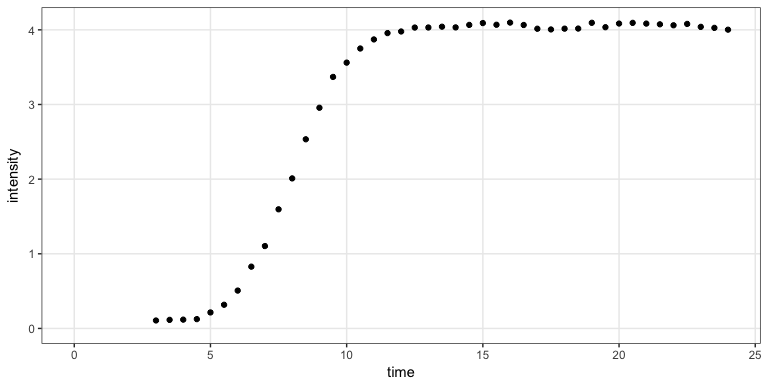

```r
# Sigmoidal Raw Data
fig01a=sicegar::figureModelCurves(dataInput=normalizedSigmoidalInput)
print(fig01a)
```

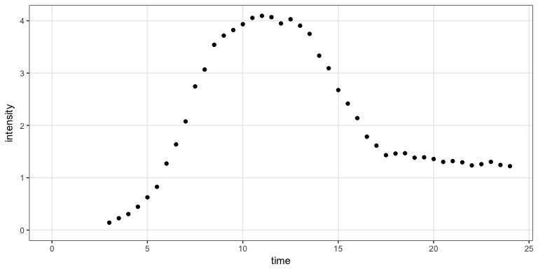

```r
# Double Sigmoidal Raw Data
fig01b=sicegar::figureModelCurves(dataInput=normalizedDoubleSigmoidalInput)
print(fig01b)
```

or we can generate raw data with fits

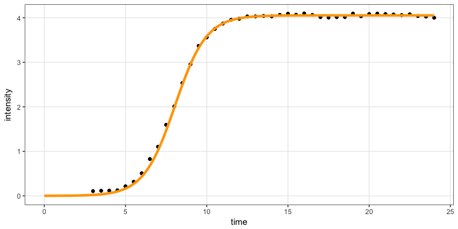

```r
# Sigmoidal Fit
fig02a=sicegar::figureModelCurves(dataInput=normalizedSigmoidalInput,
                                  sigmoidalFitVector=sigmoidalModel)
print(fig02a)
```

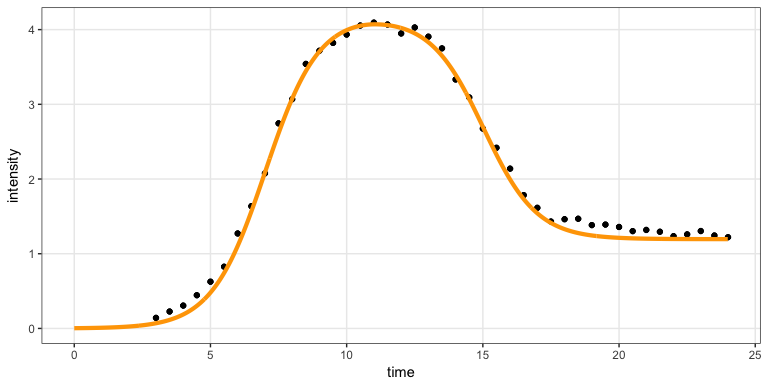

```r
# Double Sigmoidal Fit
fig02b=sicegar::figureModelCurves(dataInput=normalizedDoubleSigmoidalInput,
                                  doubleSigmoidalFitVector=doubleSigmoidalModel)
print(fig02b)
```

We can see the quantified parameters on the figues too; by the help of `showParameterRelatedLines=TRUE` option

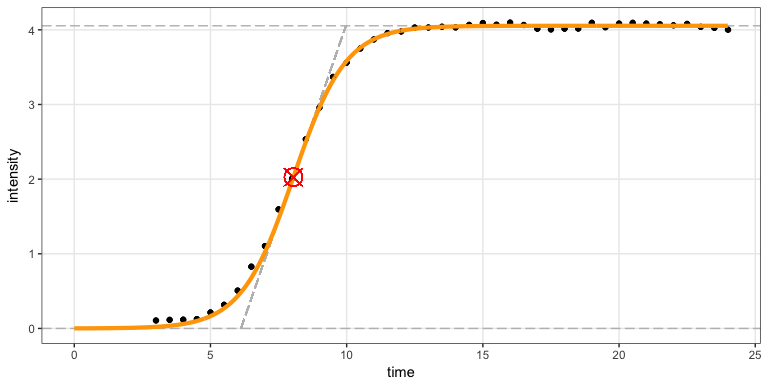

```r
# Sigmoidal Fit with parameter related lines
fig03a=sicegar::figureModelCurves(dataInput=normalizedSigmoidalInput,
                                  sigmoidalFitVector=sigmoidalModel,
                                  showParameterRelatedLines=TRUE)
print(fig03a)
```

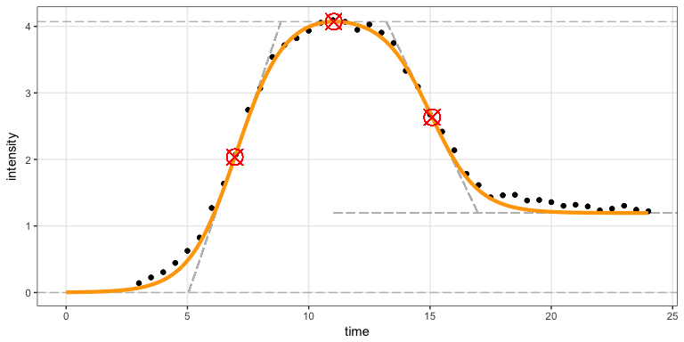

```r
# Double Sigmoidal Fit with parameter related lines
fig03b=sicegar::figureModelCurves(dataInput=normalizedDoubleSigmoidalInput,
                                  doubleSigmoidalFitVector=doubleSigmoidalModel,
                                  showParameterRelatedLines=TRUE)
print(fig03b)
```